# Final Exam Take-home

Gus Lipkin ~ glipkin6737@floridapoly.edu

> This take-home model estimation work in R accounts for 40 points on your midterm exam. Please ensure the guidelines for submissions are followed to receive full credit. Late submissions will not be accepted.

> Please include relevant explanation of your results in your R notebook. You may turn in a html file or knit pdf file.

```r
library(tidyverse)
library(data.table)
library(ISLR2)
library(caret)
library(MLeval)
library(factoextra)
library(NbClust)
```

# Problem 1 (15 points)

> Use the OJ dataset from the textbook’s ISLR2 library to answer the following questions

```r
# load data
oj <- data.table(ISLR2::OJ)

# recode columns
factorCols <- c("StoreID", "STORE")
oj[, (factorCols) := lapply(.SD, as.factor), .SDcols = factorCols]
logicalCols <- c("SpecialCH", "SpecialMM")
oj[, (logicalCols) := lapply(.SD, as.logical), .SDcols = logicalCols]

# preview the data
head(oj)
```

| Purchase | WeekofPurchase | StoreID | PriceCH | PriceMM | DiscCH | DiscMM | SpecialCH | SpecialMM | LoyalCH | SalePriceMM | SalePriceCH | PriceDiff | Store7 | PctDiscMM | PctDiscCH | ListPriceDiff | STORE |
| --- | --- | --- | --- | --- | --- | --- | --- | --- | --- | --- | --- | --- | --- | --- | --- | --- | --- |
| CH | 237 | 1 | 1.75 | 1.99 | 0.00 | 0.0 | FALSE | FALSE | 0.500000 | 1.99 | 1.75 | 0.24 | No | 0.000000 | 0.000000 | 0.24 | 1 |
| CH | 239 | 1 | 1.75 | 1.99 | 0.00 | 0.3 | FALSE | TRUE | 0.600000 | 1.69 | 1.75 | -0.06 | No | 0.150754 | 0.000000 | 0.24 | 1 |
| CH | 245 | 1 | 1.86 | 2.09 | 0.17 | 0.0 | FALSE | FALSE | 0.680000 | 2.09 | 1.69 | 0.40 | No | 0.000000 | 0.091398 | 0.23 | 1 |
| MM | 227 | 1 | 1.69 | 1.69 | 0.00 | 0.0 | FALSE | FALSE | 0.400000 | 1.69 | 1.69 | 0.00 | No | 0.000000 | 0.000000 | 0.00 | 1 |
| CH | 228 | 7 | 1.69 | 1.69 | 0.00 | 0.0 | FALSE | FALSE | 0.956535 | 1.69 | 1.69 | 0.00 | Yes | 0.000000 | 0.000000 | 0.00 | 0 |
| CH | 230 | 7 | 1.69 | 1.99 | 0.00 | 0.0 | FALSE | TRUE | 0.965228 | 1.99 | 1.69 | 0.30 | Yes | 0.000000 | 0.000000 | 0.30 | 0 |

## a

> Provide a data dictionary and summary statistics of the data.

### Data Dictionary

| Variable | Description | Type |
| --- | --- | --- |
| Purchase | A factor with levels `CH` and `MM`indicating whether the customer purchased Citrus Hill or Minute Maid Orange Juice | Factor |
| WeekOfPurchase | Week of purchase | Numeric |
| StoreID | Store ID | Factor |
| PriceCH | Price charged for CH | Numeric |
| PriceMM | Price charged for MM | Numeric |
| DiscCH | Discount offered for CH | Numeric |
| DiscMM | Discount offered for MM | Numeric |
| SpecialCH | Indicator of special on CH | Logical |
| SpecialMM | Indicator of special on MM | Logical |
| LoyalCH | Customer brand loyalty for CH | Numeric |
| SalePriceMM | Sale price for MM | Numeric |
| SalePriceCH | Sale price for CH | Numeric |
| PriceDiff | Sale price of MM less sale price of CH | Numeric |
| Store7 | A factor with levels `No` and `Yes` indicating whether the sale is at Store 7 | Factor |
| PctDiscMM | Percentage discount for MM | Numeric |
| PctDiscCH | Percentage discount for CH | Numeric |
| ListPriceDiff | List price of MM less list price of CH | Numeric |
| STORE | Which of the 5 possible stores the sale occured at | Factor |

### Summary Statistics

```r
summary(oj)
```

```
 Purchase WeekofPurchase  StoreID    PriceCH         PriceMM          DiscCH            DiscMM       SpecialCH
 CH:653   Min.   :227.0   1:157   Min.   :1.690   Min.   :1.690   Min.   :0.00000   Min.   :0.0000   Mode :logical
 MM:417   1st Qu.:240.0   2:222   1st Qu.:1.790   1st Qu.:1.990   1st Qu.:0.00000   1st Qu.:0.0000   FALSE:912
          Median :257.0   3:196   Median :1.860   Median :2.090   Median :0.00000   Median :0.0000   TRUE :158
          Mean   :254.4   4:139   Mean   :1.867   Mean   :2.085   Mean   :0.05186   Mean   :0.1234
          3rd Qu.:268.0   7:356   3rd Qu.:1.990   3rd Qu.:2.180   3rd Qu.:0.00000   3rd Qu.:0.2300
          Max.   :278.0           Max.   :2.090   Max.   :2.290   Max.   :0.50000   Max.   :0.8000
 SpecialMM          LoyalCH          SalePriceMM     SalePriceCH      PriceDiff       Store7      PctDiscMM        PctDiscCH
 Mode :logical   Min.   :0.000011   Min.   :1.190   Min.   :1.390   Min.   :-0.6700   No :714   Min.   :0.0000   Min.   :0.00000
 FALSE:897       1st Qu.:0.325257   1st Qu.:1.690   1st Qu.:1.750   1st Qu.: 0.0000   Yes:356   1st Qu.:0.0000   1st Qu.:0.00000
 TRUE :173       Median :0.600000   Median :2.090   Median :1.860   Median : 0.2300             Median :0.0000   Median :0.00000
                 Mean   :0.565782   Mean   :1.962   Mean   :1.816   Mean   : 0.1465             Mean   :0.0593   Mean   :0.02731
                 3rd Qu.:0.850873   3rd Qu.:2.130   3rd Qu.:1.890   3rd Qu.: 0.3200             3rd Qu.:0.1127   3rd Qu.:0.00000
                 Max.   :0.999947   Max.   :2.290   Max.   :2.090   Max.   : 0.6400             Max.   :0.4020   Max.   :0.25269
 ListPriceDiff   STORE
 Min.   :0.000   0:356
 1st Qu.:0.140   1:157
 Median :0.240   2:222
 Mean   :0.218   3:196
 3rd Qu.:0.300   4:139
 Max.   :0.440
```

## b

> Create a training and test dataset with 80-20 split.

```r
set.seed(2022)
rowPicker <- createDataPartition(y=oj$Purchase, p=0.8, list=FALSE)
train <- oj[rowPicker]
test <- oj[-rowPicker]

control <- trainControl(method = "cv", number = 10, classProbs = TRUE,
                        summaryFunction = twoClassSummary,
                        savePredictions = TRUE)
```

## c

> Fit a support vector classifier with Purchase as the response variable and other variables as independent variables.

```r
tGrid <- expand.grid(C = c(.01, .05, .1, .25, .5, .75, 1, 1.25, 5, 10))
svmModel <- train(Purchase ~ ., train, method = "svmLinear", tuneGrid = tGrid,
                  trControl = control, metric = "ROC",
                  preProcess = c("center", "scale"))
svmModel
```

```
Support Vector Machines with Linear Kernel

857 samples
 17 predictor
  2 classes: 'CH', 'MM'

Pre-processing: centered (23), scaled (23)
Resampling: Cross-Validated (10 fold)
Summary of sample sizes: 772, 771, 772, 771, 771, 771, ...
Resampling results across tuning parameters:

  C      ROC        Sens       Spec
   0.01  0.8841046  0.8699927  0.7367201
   0.05  0.8878938  0.8642598  0.7485740
   0.10  0.8866869  0.8700290  0.7455437
   0.25  0.8870191  0.8623367  0.7514260
   0.50  0.8867842  0.8700290  0.7425134
   0.75  0.8860996  0.8700290  0.7455437
   1.00  0.8865562  0.8700290  0.7394831
   1.25  0.8870817  0.8700290  0.7394831
   5.00  0.8865063  0.8681060  0.7365419
  10.00  0.8858724  0.8795356  0.7393048

ROC was used to select the optimal model using the largest value.
The final value used for the model was C = 0.05.
```

```r
svmPred <- predict(svmModel, test)
confusionMatrix(svmPred, test$Purchase)
```

```
Confusion Matrix and Statistics

          Reference
Prediction  CH  MM
        CH 117  17
        MM  13  66

               Accuracy : 0.8592
                 95% CI : (0.8051, 0.9029)
    No Information Rate : 0.6103
    P-Value [Acc > NIR] : 1.265e-15

                  Kappa : 0.7013

 Mcnemar's Test P-Value : 0.5839

            Sensitivity : 0.9000
            Specificity : 0.7952
         Pos Pred Value : 0.8731
         Neg Pred Value : 0.8354
             Prevalence : 0.6103
         Detection Rate : 0.5493
   Detection Prevalence : 0.6291
      Balanced Accuracy : 0.8476

       'Positive' Class : CH
```

## d

> Fit a support vector machine with a radial kernel.

```r
rGrid <- expand.grid(C = c(.1, .25, .5, .75, 1, 1.25, 1.5),
                     sigma = c(1e-3, 1e-2, 1e-1))
radModel <- train(Purchase ~ ., train, method = "svmRadial", tuneGrid = rGrid,
                  trControl = control, metric = "ROC",
                  preProcess = c("center", "scale"))
radModel
```

```
Support Vector Machines with Radial Basis Function Kernel

857 samples
 17 predictor
  2 classes: 'CH', 'MM'

Pre-processing: centered (23), scaled (23)
Resampling: Cross-Validated (10 fold)
Summary of sample sizes: 771, 771, 771, 771, 771, 772, ...
Resampling results across tuning parameters:

  C     sigma  ROC        Sens       Spec
  0.10  0.001  0.8534462  0.7285922  0.8173797
  0.10  0.010  0.8560336  0.7648766  0.7784314
  0.10  0.100  0.8496766  0.8205007  0.7065062
  0.25  0.001  0.8534462  0.7266691  0.8203209
  0.25  0.010  0.8790143  0.8491655  0.7367201
  0.25  0.100  0.8555933  0.8703193  0.7065062
  0.50  0.001  0.8533890  0.7324020  0.8144385
  0.50  0.010  0.8841571  0.8664006  0.7365419
  0.50  0.100  0.8594063  0.8721698  0.7065954
  0.75  0.001  0.8613951  0.7859579  0.7694296
  0.75  0.010  0.8862136  0.8683599  0.7214795
  0.75  0.100  0.8622732  0.8664731  0.7037433
  1.00  0.001  0.8677613  0.8146952  0.7485740
  1.00  0.010  0.8882831  0.8722424  0.7277184
  1.00  0.100  0.8618158  0.8759434  0.7036542
  1.25  0.001  0.8723909  0.8223149  0.7546346
  1.25  0.010  0.8877105  0.8760160  0.7337790
  1.25  0.100  0.8632953  0.8835631  0.7067736
  1.50  0.001  0.8774369  0.8338171  0.7425134
  1.50  0.010  0.8873777  0.8664369  0.7248663
  1.50  0.100  0.8623714  0.8835631  0.7007130

ROC was used to select the optimal model using the largest value.
The final values used for the model were sigma = 0.01 and C = 1.
```

```r
radPred <- predict(radModel, test)
confusionMatrix(radPred, test$Purchase)
```

```
Confusion Matrix and Statistics

          Reference
Prediction  CH  MM
        CH 119  17
        MM  11  66

               Accuracy : 0.8685
                 95% CI : (0.8156, 0.9108)
    No Information Rate : 0.6103
    P-Value [Acc > NIR] : <2e-16

                  Kappa : 0.72

 Mcnemar's Test P-Value : 0.3447

            Sensitivity : 0.9154
            Specificity : 0.7952
         Pos Pred Value : 0.8750
         Neg Pred Value : 0.8571
             Prevalence : 0.6103
         Detection Rate : 0.5587
   Detection Prevalence : 0.6385
      Balanced Accuracy : 0.8553

       'Positive' Class : CH
```

## e

> Fit a support vector machine with a polynomial kernel.

```r
polyModel <- train(Purchase ~ ., train, method = "svmPoly",
                  trControl = control, metric = "ROC",
                  preProcess = c("center", "scale"))
polyModel
```

```
Support Vector Machines with Polynomial Kernel

857 samples
 17 predictor
  2 classes: 'CH', 'MM'

Pre-processing: centered (23), scaled (23)
Resampling: Cross-Validated (10 fold)
Summary of sample sizes: 772, 772, 771, 771, 771, 771, ...
Resampling results across tuning parameters:

  degree  scale  C     ROC        Sens       Spec
  1       0.001  0.25  0.8629344  0.7324746  0.8108734
  1       0.001  0.50  0.8631047  0.7305515  0.8200535
  1       0.001  1.00  0.8630475  0.7343251  0.8079323
```

[output cut: 27 more lines]

```r
polyPred <- predict(polyModel, test)
confusionMatrix(polyPred, test$Purchase)
```

```
Confusion Matrix and Statistics

          Reference
Prediction  CH  MM
        CH 117  16
        MM  13  67

               Accuracy : 0.8638
                 95% CI : (0.8104, 0.9069)
    No Information Rate : 0.6103
    P-Value [Acc > NIR] : 3.189e-16

                  Kappa : 0.7119

 Mcnemar's Test P-Value : 0.7103

            Sensitivity : 0.9000
            Specificity : 0.8072
         Pos Pred Value : 0.8797
         Neg Pred Value : 0.8375
             Prevalence : 0.6103
         Detection Rate : 0.5493
   Detection Prevalence : 0.6244
      Balanced Accuracy : 0.8536

       'Positive' Class : CH
```

## f

> Which classifier performs best?

```
***MLeval: Machine Learning Model Evaluation***
Input: caret train function object
Not averaging probs.
Group 1 type: cv
Group 2 type: cv
Group 3 type: cv
Observations: 2571
Number of groups: 3
Observations per group: 857
Positive: MM
Negative: CH
Group: Linear SVC
Positive: 334
Negative: 523
Group: Radial SVM
Positive: 334
Negative: 523
Group: Polynomial SVM
Positive: 334
Negative: 523
***Performance Metrics***
Linear SVC Optimal Informedness = 0.661911358926506
Radial SVM Optimal Informedness = 0.637232227705201
Polynomial SVM Optimal Informedness = 0.645206718494178
Linear SVC AUC-ROC = 0.89
Radial SVM AUC-ROC = 0.89
Polynomial SVM AUC-ROC = 0.89
```

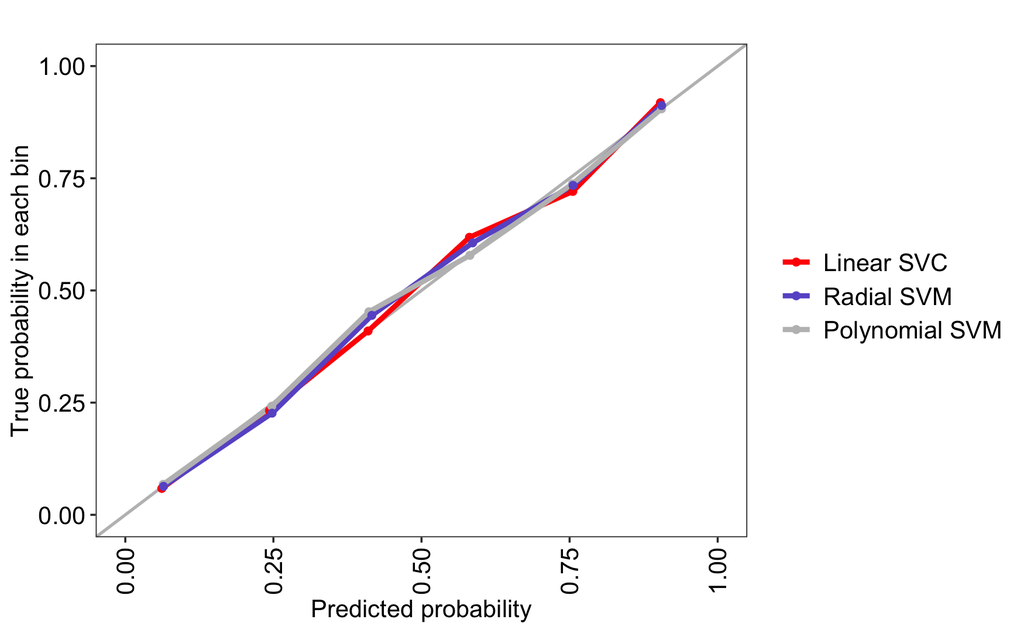

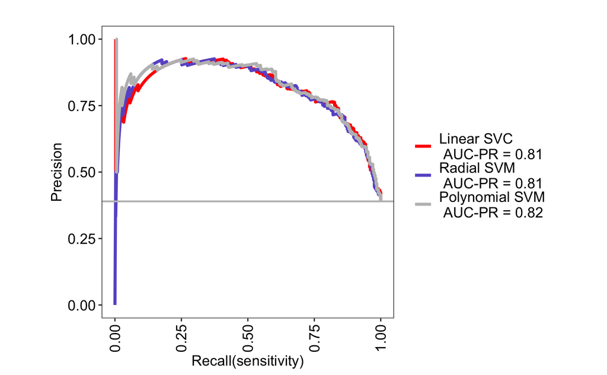

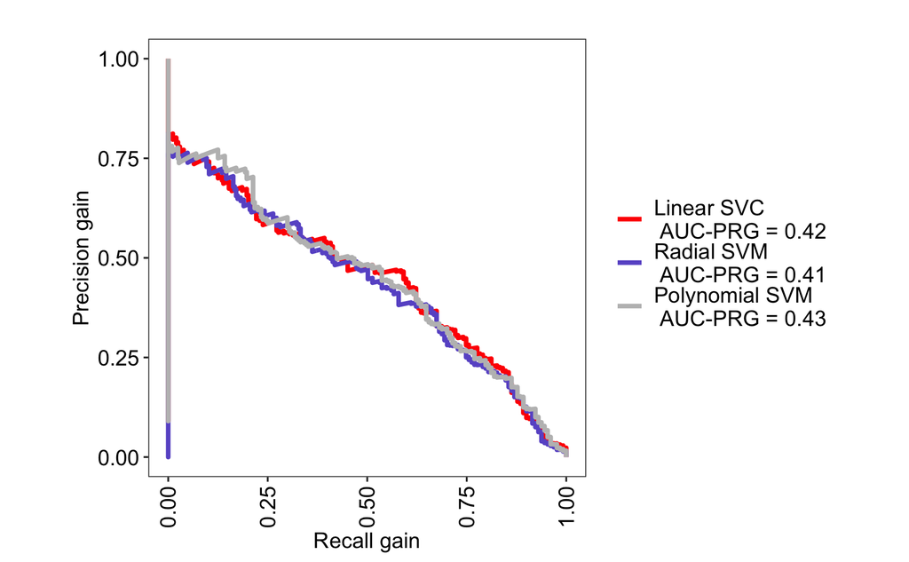

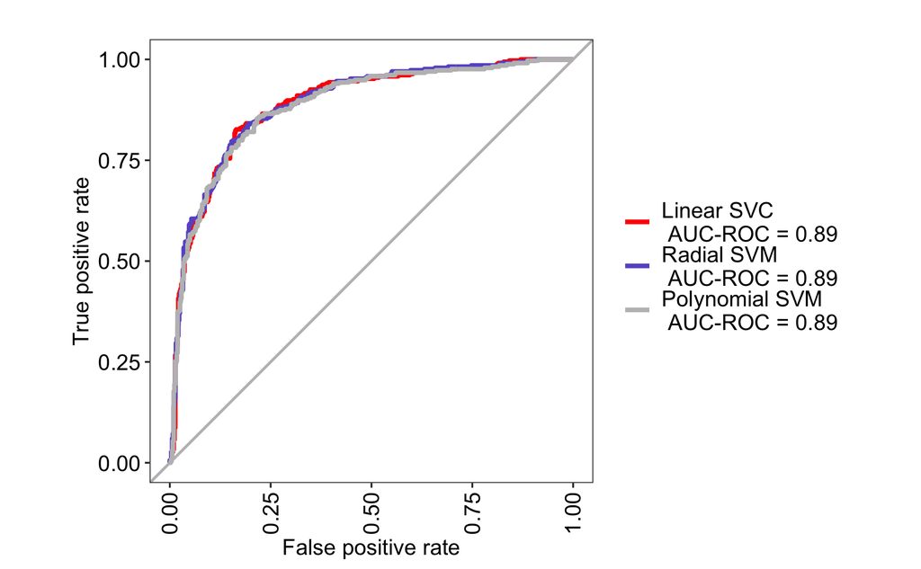

```r
plot_comp <- evalm(list1 = list(svmModel, radModel, polyModel),
                   gnames = c("Linear SVC", "Radial SVM", "Polynomial SVM"))
```

# Problem 2 (10 points)

> Use the cereals data on CANVAS (Used this in R classwork on PCA) to perform K-means and hierarchical clustering. Please do not forget to remove missing values if any and include relevant plots. Also include data dictionary and summary statistics.

```r
# load data
cereals <- fread("../../Labs/Data/CerealData.csv")

# remove missing values
cereals <- na.omit(cereals)
```

## Data Dictionary

| Variable | Description | Type |
| --- | --- | --- |
| name | Name of cereal | Character |
| mfr | Manufacturer of cereal A = American Home Food Products G = General Mills K = Kelloggs N = Nabisco P = Post Q = Quaker Oats R = Ralston Purina | Factor |
| type | hot, cold | Factor |
| calories | calories per serving | Numeric |
| protein | grams of protein | Numeric |
| fat | grams of fat | Numeric |
| sodium | milligrams of sodium | Numeric |
| fiber | grams of dietary fiber | Numeric |
| carbo | grams of complex carbohydrates | Numeric |
| sugars | grams of sugars | Numeric |
| potass | milligrams of potassium | Numeric |
| vitamins | vitamins and minerals - 0, 25, or 100, indicating the typical percentage of FDA recommended | Factor |
| shelf | display shelf (1, 2, 3, counting from the floor) | Factor |
| weight | weight in ounces of one serving | Numeric |
| cups | number of cups in one serving | Numeric |
| rating | rating of the cereals | Numeric |

## Summary Statistics

```r
# remove the name column
cereals <- cereals[, !c("name")]
summary(cereals)
```

```
     mfr                type              calories      protein           fat        sodium          fiber            carbo
 Length:74          Length:74          Min.   : 50   Min.   :1.000   Min.   :0   Min.   :  0.0   Min.   : 0.000   Min.   : 5.00
 Class :character   Class :character   1st Qu.:100   1st Qu.:2.000   1st Qu.:0   1st Qu.:135.0   1st Qu.: 0.250   1st Qu.:12.00
 Mode  :character   Mode  :character   Median :110   Median :2.500   Median :1   Median :180.0   Median : 2.000   Median :14.50
                                       Mean   :107   Mean   :2.514   Mean   :1   Mean   :162.4   Mean   : 2.176   Mean   :14.73
                                       3rd Qu.:110   3rd Qu.:3.000   3rd Qu.:1   3rd Qu.:217.5   3rd Qu.: 3.000   3rd Qu.:17.00
                                       Max.   :160   Max.   :6.000   Max.   :5   Max.   :320.0   Max.   :14.000   Max.   :23.00
     sugars           potass          vitamins          shelf           weight           cups            rating
 Min.   : 0.000   Min.   : 15.00   Min.   :  0.00   Min.   :1.000   Min.   :0.500   Min.   :0.2500   Min.   :18.04
 1st Qu.: 3.000   1st Qu.: 41.25   1st Qu.: 25.00   1st Qu.:1.250   1st Qu.:1.000   1st Qu.:0.6700   1st Qu.:32.45
 Median : 7.000   Median : 90.00   Median : 25.00   Median :2.000   Median :1.000   Median :0.7500   Median :40.25
 Mean   : 7.108   Mean   : 98.51   Mean   : 29.05   Mean   :2.216   Mean   :1.031   Mean   :0.8216   Mean   :42.37
 3rd Qu.:11.000   3rd Qu.:120.00   3rd Qu.: 25.00   3rd Qu.:3.000   3rd Qu.:1.000   3rd Qu.:1.0000   3rd Qu.:50.52
 Max.   :15.000   Max.   :330.00   Max.   :100.00   Max.   :3.000   Max.   :1.500   Max.   :1.5000   Max.   :93.70
```

## Hierarchical Clustering

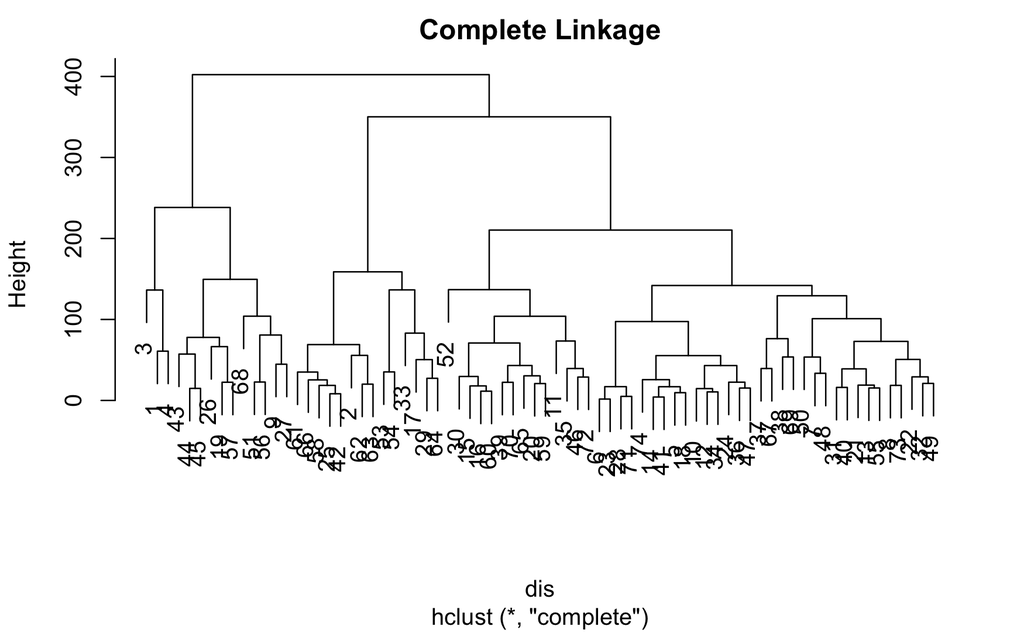

```r
cereals <- cereals[, .(calories, protein, fat, sodium, fiber, carbo, sugars, potass, vitamins, shelf, weight, cups, rating)]
dis <- dist(cereals)
hc <- hclust(dis, method = "complete")
plot(hc, main="Complete Linkage")
```

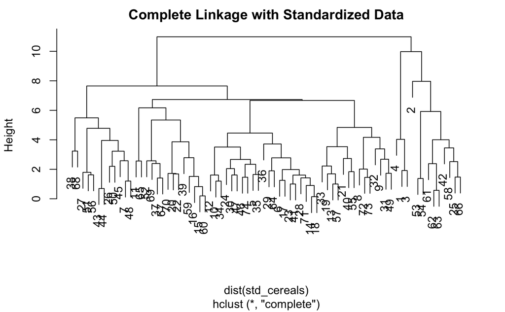

```r
std_cereals <- scale(cereals, center = T, scale = T)
hc_std <- hclust(dist(std_cereals), method = "complete")
plot(hc_std, main = "Complete Linkage with Standardized Data")
```

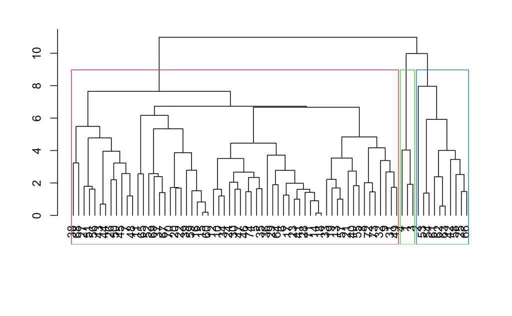

```r
plot(hc_std, ann=FALSE, hang = -1)
rect.hclust(hc_std, k=3, border=2:5)
```

## K-Means Clustering

The third hierarchical clustering plot suggests that three clusters is optimal, but I want to double check.

```
*** : The Hubert index is a graphical method of determining the number of clusters.
                In the plot of Hubert index, we seek a significant knee that corresponds to a
                significant increase of the value of the measure i.e the significant peak in Hubert
                index second differences plot.
```

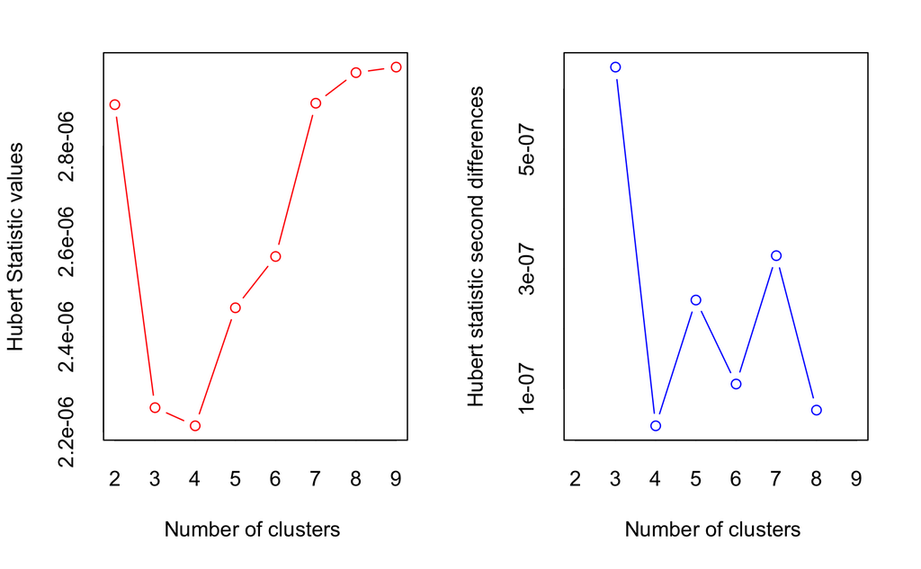

```
*** : The D index is a graphical method of determining the number of clusters.
                In the plot of D index, we seek a significant knee (the significant peak in Dindex
                second differences plot) that corresponds to a significant increase of the value of
                the measure.

* Among all indices:
* 3 proposed 2 as the best number of clusters
* 10 proposed 3 as the best number of clusters
* 2 proposed 4 as the best number of clusters
* 1 proposed 5 as the best number of clusters
* 3 proposed 7 as the best number of clusters
* 3 proposed 8 as the best number of clusters
* 2 proposed 9 as the best number of clusters

                   ***** Conclusion *****

* According to the majority rule, the best number of clusters is  3
```

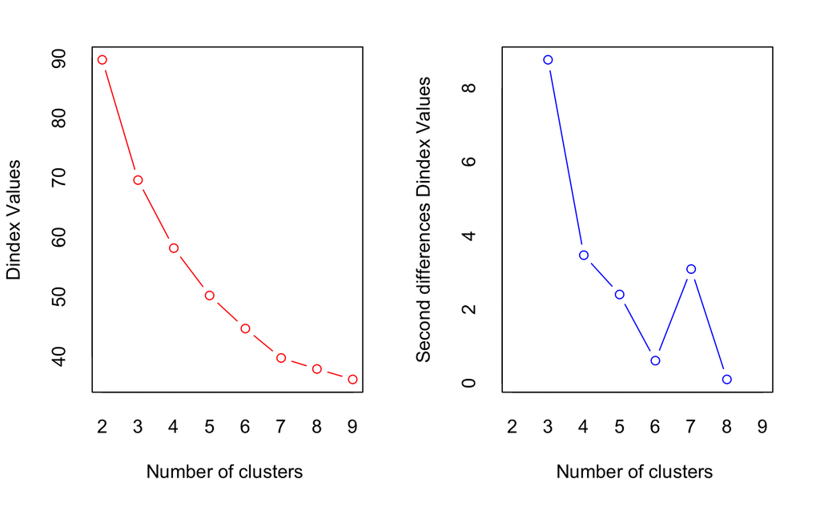

```r
res.nbclust <- NbClust(cereals[, .(calories, protein, fat, sodium, fiber, carbo,
                             sugars, potass, weight, cups, rating)],
                       distance = "euclidean", min.nc = 2, max.nc = 9,
                  method = "complete", index ="all")
```

```
Among all indices:
===================
* 2 proposed  0 as the best number of clusters
* 3 proposed  2 as the best number of clusters
* 10 proposed  3 as the best number of clusters
* 2 proposed  4 as the best number of clusters
* 1 proposed  5 as the best number of clusters
* 3 proposed  7 as the best number of clusters
* 3 proposed  8 as the best number of clusters
* 2 proposed  9 as the best number of clusters

Conclusion
=========================
* According to the majority rule, the best number of clusters is  3 .
```

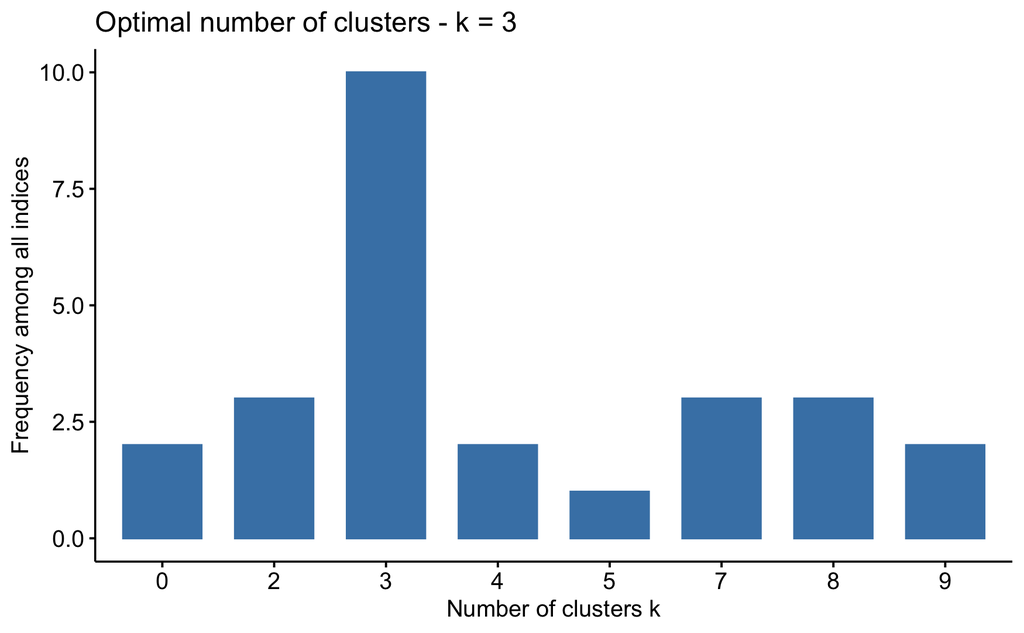

```r
factoextra::fviz_nbclust(res.nbclust)
```

3 is optimal.

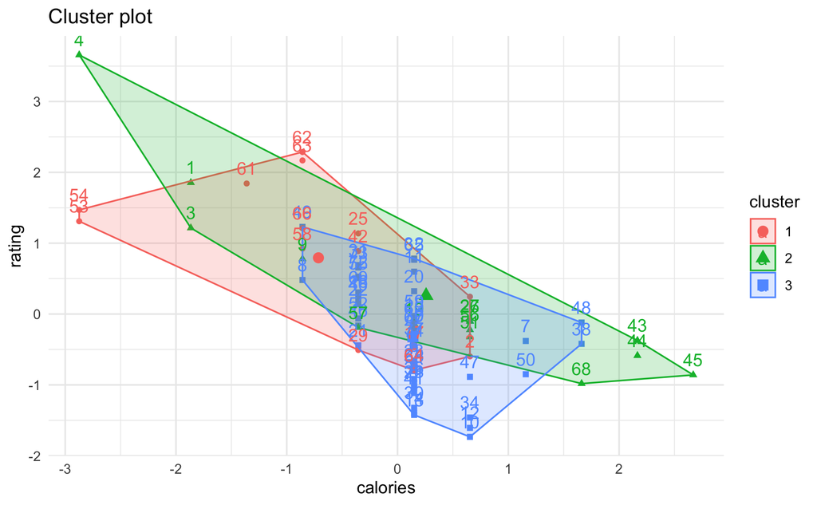

```r
kmeans <- kmeans(cereals[, .(calories, protein, fat, sodium, fiber, carbo,
                             sugars, potass, weight, cups, rating)], 3)
cereals$test <- as.factor(kmeans$cluster)

fviz_cluster(kmeans, data = cereals, choose.vars = c("calories", "rating")) +
  theme_minimal()
```

I was curious if calories had any impact on rating and if they were grouped. The two variables seem to have some impact, but don’t tell the whole story. Maybe we should test if Honey Bunches of Oats clusters better?

# Problem 3 (15 Points)

> Use the USArrests data from the textbook (ISLR2 library) to perform PCA. Please ensure to include the plots.

```r
head(USArrests)
```

|  | Murder | Assault | UrbanPop | Rape |
| --- | --- | --- | --- | --- |
| Alabama | 13.2 | 236 | 58 | 21.2 |
| Alaska | 10.0 | 263 | 48 | 44.5 |
| Arizona | 8.1 | 294 | 80 | 31.0 |
| Arkansas | 8.8 | 190 | 50 | 19.5 |
| California | 9.0 | 276 | 91 | 40.6 |
| Colorado | 7.9 | 204 | 78 | 38.7 |

```r
arrests_pca <- prcomp(USArrests, scale. = T)
summary(arrests_pca)
```

```
Importance of components:
                          PC1    PC2     PC3     PC4
Standard deviation     1.5749 0.9949 0.59713 0.41645
Proportion of Variance 0.6201 0.2474 0.08914 0.04336
Cumulative Proportion  0.6201 0.8675 0.95664 1.00000
```

```r
arrests_pca$rotation
```

```
                PC1        PC2        PC3         PC4
Murder   -0.5358995  0.4181809 -0.3412327  0.64922780
Assault  -0.5831836  0.1879856 -0.2681484 -0.74340748
UrbanPop -0.2781909 -0.8728062 -0.3780158  0.13387773
Rape     -0.5434321 -0.1673186  0.8177779  0.08902432
```

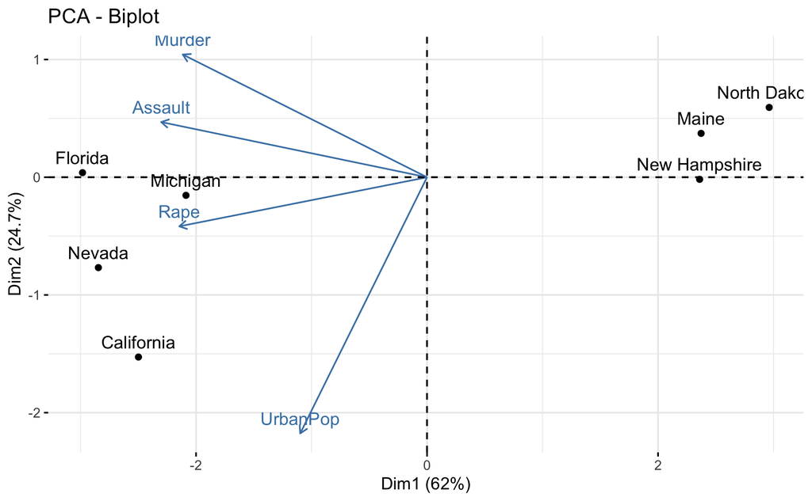

```r
fviz_pca_biplot(arrests_pca,
                select.ind = list(names = c("Florida", "Nevada", "California",
                                            "Michigan", "New Hampshire", "Maine",
                                            "North Dakota")))
```